# Examining Police Misconduct: Evidence from Chicago

I will study data from the Citizens Police Data Project which can be accessed via [their website](https://www.cpdp.co). The datasets can be downloaded at different grouping levels such as police districts, wards, beat, and neighborhoods. The data are presented in comma-separated value files that contain different variables describing the characteristics of the interaction between the police officer and the complaining witness.

You can access the data and code that I used to clean the data files here.

I will start by providing you with a couple of visualizations that are very interesting in order to understand what’s going on within the Chicago PD.

We will need the following packages:

```r
devtools::source_url("https://github.com/sebmontenegro/functions/blob/master/preload.R?raw=TRUE")

preload("tidyverse")
preload("readxl")
preload("dplyr")
preload("zoo")
preload("stringr")
```

The `preload` function can be accessed via Internet from my GitHub. I created this function to load packages and/or install them on the system when they are not already installed.

## Over time

This is how the number of allegations of both overtime for the Chicago PD

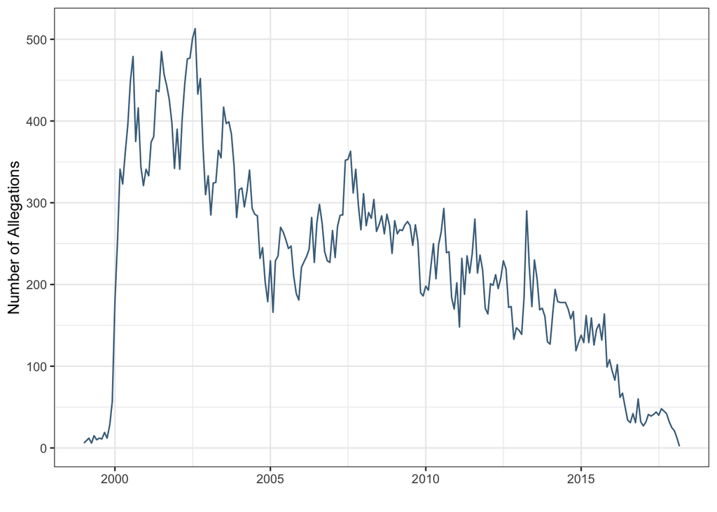

```r
allegations %>%
  filter(IncidentDate>=as.Date("1999-01-01")) %>%
  count(Date = factor(IncidentDate)) %>%
  ggplot(aes(x=as.Date(Date),y=n))+
  geom_line(color="skyblue4")+
  theme_bw()+
  labs(x ="", y = "Number of Allegations")
```

It has a downward trend and has a drop in 2005 and 2016.

## Most frequent allegation categories

This next plot presents the most frequent allegation category by finding.

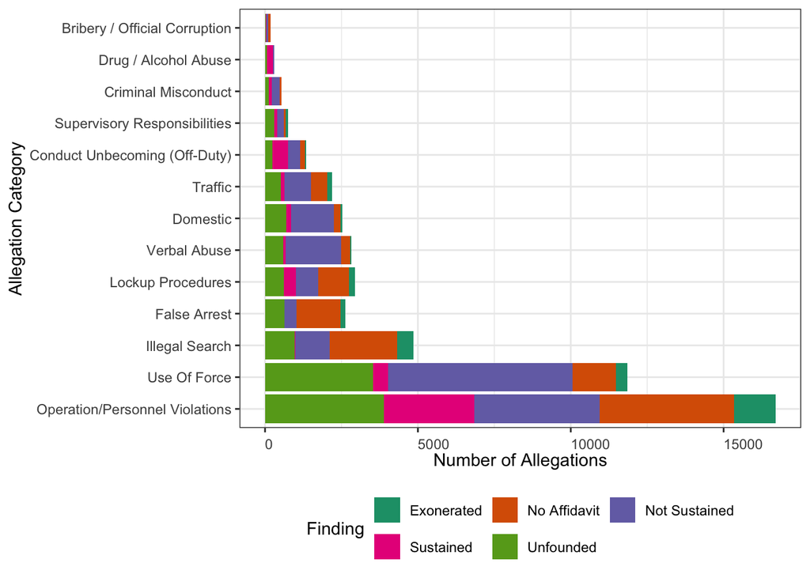

```r
allegations %>%
  filter(Finding!="Unknown") %>%
  count(Category = Category, Finding = Finding) %>%
  filter(n>=15) %>%
  ggplot(aes(x=reorder(Category,-n),y=n,fill=Finding))+
  geom_bar(stat = "identity")+
  theme_bw()+
  labs(x ="Allegation Category", y = "Number of Allegations")+coord_flip()+
  scale_fill_brewer(palette="Dark2")+
  guides(fill=guide_legend(nrow=2,byrow=TRUE))+
  theme(axis.text.x = element_text(angle = 0, vjust = 0, hjust=0),legend.position = "bottom")
```

The most frequent category is **Operation/Personnel Violations**. However, those allegations may be *sustained*, *not sustained*, *unfounded*, *exonerated*, or the allegation might be filed with *no affidavit*.

## Most frequent allegation type

The following represents the most frequent allegation type of served in the data.

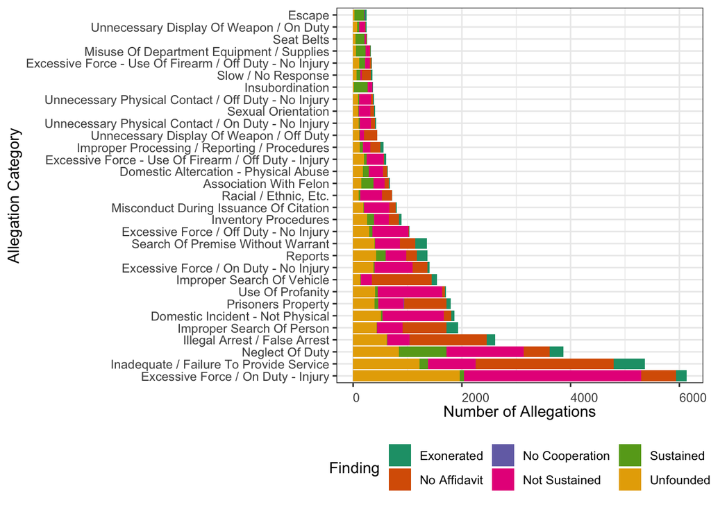

```r
allegations %>%
  filter(Finding!="Unknown"&Allegation!="Miscellaneous") %>%
  count(Allegation = Allegation, Category = Category) %>%
  filter(n>=230) %>%
  arrange(desc(n)) -> tmp

merge(tmp[,-3],
allegations %>%
  filter(Finding!="Unknown"&Allegation!="Miscellaneous") %>%
  count(Finding = Finding, Allegation = Allegation),
by="Allegation",all.x = T,all.y = F) %>%
  ggplot(aes(x=factor(Allegation,levels = tmp$Allegation),y=n,fill=Finding))+
  geom_bar(stat = "identity")+ #facet_wrap(~District,nrow=4)+
  theme_bw()+
  labs(x ="Allegation Category", y = "Number of Allegations")+coord_flip()+
  scale_fill_brewer(palette="Dark2")+
  theme(axis.text.x = element_text(angle = 0, vjust = 0, hjust=0),legend.position = "bottom")
```

## Final outcome and finding

Now, let’s explore final outcome for allegations recorded in the data. The outcome-axis is order in frequency, so that *No Action Taken* is the most frequent.

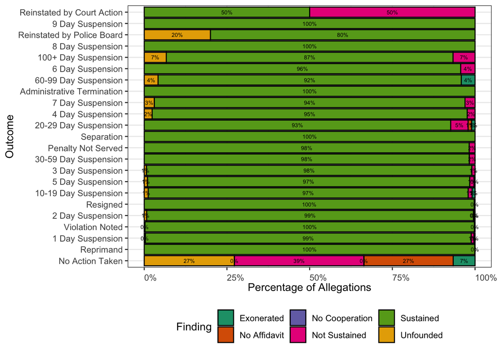

```r
allegations %>%
  filter(Outcome!="Unknown"&
           Finding!="Unknown") %>%
  count(Outcome = factor(Outcome),Finding = factor(Finding))%>%
  group_by(Outcome) %>%
  mutate(pct = prop.table(n)) %>%
  ggplot(aes(x=factor(Outcome,level=levels(forcats::fct_infreq(allegations$Outcome))),y=pct,fill=Finding))+
  geom_bar(position = "fill", stat = "identity",color='black',width=0.9) +
  scale_y_continuous(labels = scales::percent) +
  geom_text(aes(label = paste0(round(pct*100,0),"%")),position = position_stack(vjust = 0.5), size = 2)+
  theme_bw() + scale_fill_brewer(palette="Dark2")+
  labs(x ="Outcome", y = "Percentage of Allegations")+ coord_flip()+
  theme(legend.position="bottom") + theme(axis.text.x = element_text(angle = 0, vjust = 0, hjust=0))
```

## Interaction under investigation

### Race interacion frequency

Now let’s dig into the characteristics of the interaction in the data. This following graph shows the race of the officer and the race of the complaining witness.

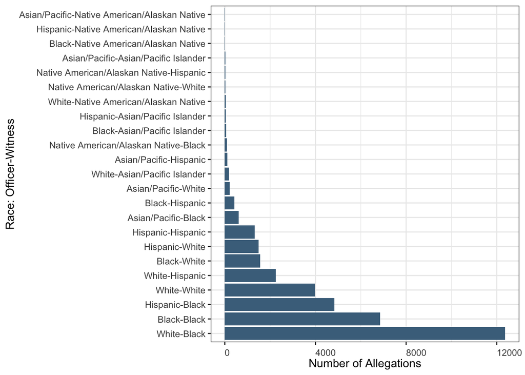

```r
all %>%
  filter(Outcome!="Unknown"&
           WitnessRace!="No Info"&
           OfficerRace!="Unknown"&
           Finding!="Unknown") %>%
  mutate(Int = paste0(OfficerRace,"-",WitnessRace)) %>%
  count(Int = Int) %>%
  ggplot(aes(x=reorder(Int,-n),y=n))+
  geom_bar(stat = "identity",fill="skyblue4")+
  theme_bw()+
  labs(x ="Race: Officer-Witness", y = "Number of Allegations")+coord_flip()+
  scale_fill_brewer(palette="Dark2")+
  theme(axis.text.x = element_text(angle = 0, vjust = 0, hjust=0),legend.position = "bottom")
```

The most frequent allegation is that involving a **White officer** and a **Black witness**.

### Race interaction and finding

Let’s look into the finding of the investigation and the officer-witness race from the interaction. The race-axis in the following plot is sorted by how frequent it is (just like the plot above).

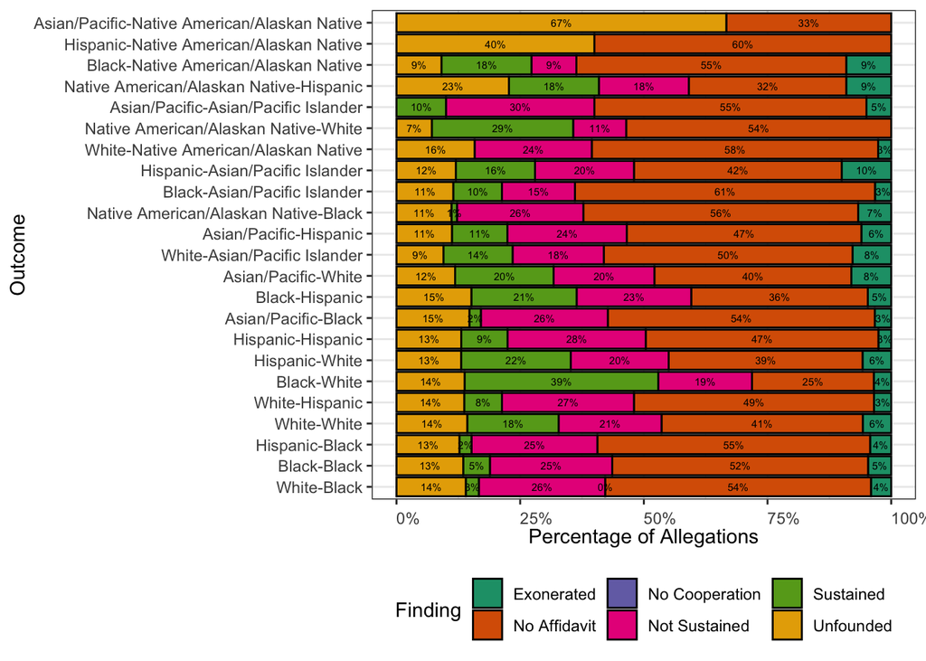

```r
all %>%
  filter(Outcome!="Unknown"&
           WitnessRace!="No Info"&
           OfficerRace!="Unknown"&
           Finding!="Unknown") %>%
  mutate(Int = paste0(OfficerRace,"-",WitnessRace)) %>%
  count(Int = factor(Int),Finding = factor(Finding))%>%
  group_by(Int) %>%
  mutate(pct = prop.table(n)) %>%
  ggplot(aes(x=factor(Int,level=levels(forcats::fct_infreq(paste0(all$OfficerRace,"-",all$WitnessRace)))),y=pct,fill=Finding))+
  geom_bar(position = "fill", stat = "identity",color='black',width=0.9) +
  scale_y_continuous(labels = scales::percent) +
  geom_text(aes(label = paste0(round(pct*100,0),"%")),position = position_stack(vjust = 0.5), size = 2)+
  theme_bw() + scale_fill_brewer(palette="Dark2")+
  labs(x ="Outcome", y = "Percentage of Allegations")+ coord_flip()+
  theme(legend.position="bottom") + theme(axis.text.x = element_text(angle = 0, vjust = 0, hjust=0))
```

### Top 10 sustained allegations by race

This is definitely no proof that allegations filed by Black citizens are being neglected or disregarded. But it would be interesting to look into all the allegations for which the investigation found the allegation *Sustained*.

The following plots show the Top 10 *Sustained* allegations for Black and White citizens, separately.

#### Black witnesses

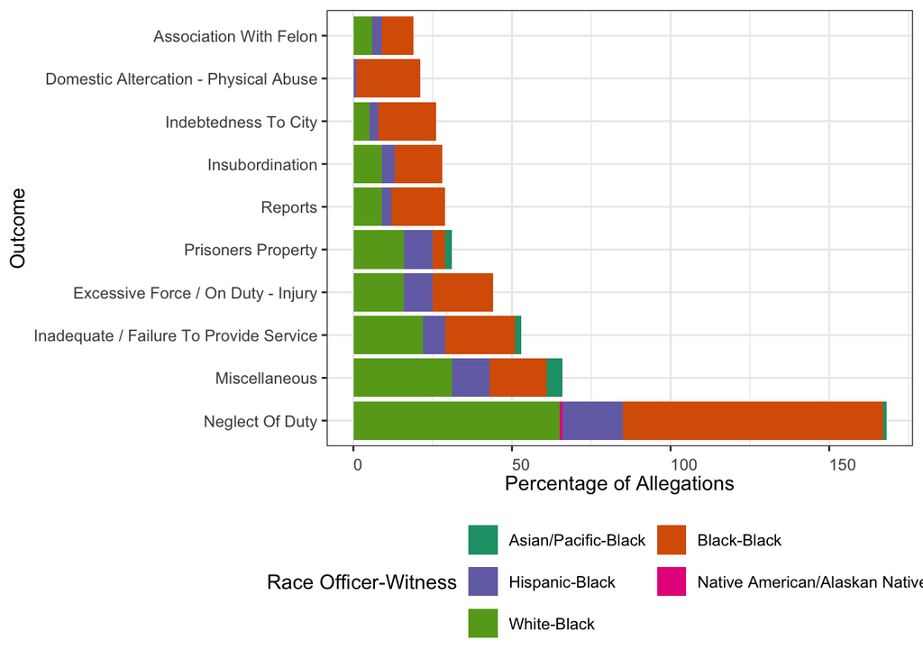

```r
a <- all %>%
  filter(Outcome!="Unknown"&
           WitnessRace=="Black"&
           OfficerRace!="Unknown"&
           Finding=="Sustained") %>%
  count(Allegation = factor(Allegation)) %>%
  arrange(desc(n)) %>%
  slice_head(n=10) #This is the top 10 for Black citizens

b <- all %>%
  filter(Outcome!="Unknown"&
           WitnessRace=="Black"&
           OfficerRace!="Unknown"&
           Finding=="Sustained") %>%
  mutate(Int = paste0(OfficerRace,"-",WitnessRace)) %>%
  count(WitnessRace = factor(WitnessRace),Int = factor(Int),Allegation = factor(Allegation))

c <- merge(a,b,by="Allegation",all.x = T,all.y = F)


c %>%
  ggplot(aes(x=factor(Allegation,levels = c(as.character(a$Allegation))),y=n.y,fill=Int))+
  geom_bar(stat = "identity") +
  theme_bw() + scale_fill_brewer(palette="Dark2")+
  labs(x ="Outcome", y = "Percentage of Allegations",fill="Race Officer-Witness")+ coord_flip()+
  guides(fill=guide_legend(nrow=3,byrow=TRUE))+
  theme(legend.position="bottom") + theme(axis.text.x = element_text(angle = 0, vjust = 0, hjust=0))
```

The most frequent *Sustained* allegation is **Neglect Of Duty** and **Excesive Force with Injury** is fourth.

#### White witnesses

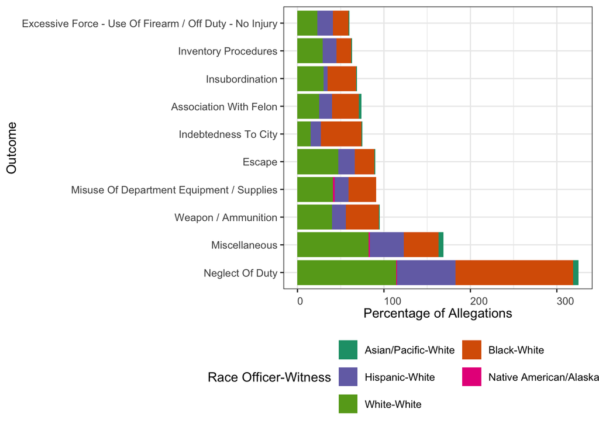

```r
a <- all %>%
  filter(Outcome!="Unknown"&
           WitnessRace=="White"&
           OfficerRace!="Unknown"&
           Finding=="Sustained") %>%
  count(Allegation = factor(Allegation)) %>%
  arrange(desc(n)) %>%
  slice_head(n=10) #This is the top 10 for White citizens

b <- all %>%
  filter(Outcome!="Unknown"&
           WitnessRace=="White"&
           OfficerRace!="Unknown"&
           Finding=="Sustained") %>%
  mutate(Int = paste0(OfficerRace,"-",WitnessRace)) %>%
  count(WitnessRace = factor(WitnessRace),Int = factor(Int),Allegation = factor(Allegation))

c <- merge(a,b,by="Allegation",all.x = T,all.y = F)


c %>%
  ggplot(aes(x=factor(Allegation,levels = c(as.character(a$Allegation))),y=n.y,fill=Int))+
  geom_bar(stat = "identity") +
  theme_bw() + scale_fill_brewer(palette="Dark2")+
  labs(x ="Outcome", y = "Percentage of Allegations",fill="Race Officer-Witness")+ coord_flip()+
  guides(fill=guide_legend(nrow=3,byrow=TRUE))+
  theme(legend.position="bottom") + theme(axis.text.x = element_text(angle = 0, vjust = 0, hjust=0))
```